# Final Project

Erin Falvey

About Me

2024-04-25

## Worldwide Coral Distribution

My aim for this project is to construct an interactive map and linear regression to determine the affect of temperature on salinity surrounding coral reefs around the world. Coral reefs are important habitats for marine life and for furthering advancement in biomedical research. Temperature and salinity are two major factors that directly impact the survival and growth of coral reefs and marine life. Previous studies have indicated that shifts in salinity and temperature caused by climate change will lead to bleaching and death within coral habitats. This is due to decreased photosynthetic efficiency which directly impacts the corals accessibility to essential nutrients. Salinity influences the distribution of different coral species within the ecosystem. Changes in salinity patterns due to factors such as rainfall, runoff, and climate change can alter the composition of these coral communities. Understanding the relationship between salinity and coral reef health is essential for effective conservation measures. With this data set, I intend to locate different regions of the globe where the water is either suitable for coral growth, or will inhibit growth.

## Data:

Here is a look at the data I have on coral distribution. This data was taken from 51 locations across the globe.

| name | salinity | January_temp | June_temp | area | latitude | longitude | type of sea | corals | silt/sulfide |
| --- | --- | --- | --- | --- | --- | --- | --- | --- | --- |
| Adriatic Sea | 38.30 | 15.66 | 20.86 | 138000 | 43 | 15 | 2 | 1 | 0 |
| Adriatic Sea | 38.30 | 16.30 | 19.50 | 138000 | 43 | 15 | 2 | 1 | 0 |
| Adriatic Sea | 38.46 | 16.25 | 19.03 | 138000 | 43 | 15 | 2 | 1 | 0 |
| Adriatic Sea | 38.12 | 15.71 | 22.88 | 138000 | 43 | 15 | 2 | 1 | 0 |
| Adriatic Sea | 38.52 | 15.73 | 21.82 | 138000 | 43 | 15 | 2 | 1 | 0 |
| Adriatic Sea | 38.06 | 16.14 | 18.59 | 138000 | 43 | 15 | 2 | 1 | 0 |
| Adriatic Sea | 38.50 | 16.25 | 21.00 | 138000 | 43 | 15 | 2 | 1 | 0 |
| Adriatic Sea | 38.33 | 16.15 | 21.46 | 138000 | 43 | 15 | 2 | 1 | 0 |
| Adriatic Sea | 38.51 | 15.69 | 23.53 | 138000 | 43 | 15 | 2 | 1 | 0 |
| Adriatic Sea | 38.33 | 16.23 | 18.59 | 138000 | 43 | 15 | 2 | 1 | 0 |
| Adriatic Sea | 38.44 | 16.23 | 20.59 | 138000 | 43 | 15 | 2 | 1 | 0 |
| Adriatic Sea | 38.49 | 15.47 | 23.76 | 138000 | 43 | 15 | 2 | 1 | 0 |
| Adriatic Sea | 38.39 | 16.30 | 21.29 | 138000 | 43 | 15 | 2 | 1 | 0 |
| Adriatic Sea | 38.41 | 15.73 | 23.70 | 138000 | 43 | 15 | 2 | 1 | 0 |
| Adriatic Sea | 38.16 | 15.54 | 23.76 | 138000 | 43 | 15 | 2 | 1 | 0 |
| Adriatic Sea | 38.32 | 15.71 | 23.91 | 138000 | 43 | 15 | 2 | 1 | 0 |
| Adriatic Sea | 38.23 | 16.19 | 21.01 | 138000 | 43 | 15 | 2 | 1 | 0 |
| Adriatic Sea | 38.40 | 16.20 | 21.46 | 138000 | 43 | 15 | 2 | 1 | 0 |
| Adriatic Sea | 38.00 | 15.67 | 23.83 | 138000 | 43 | 15 | 2 | 1 | 0 |
| Adriatic Sea | 38.31 | 15.61 | 23.92 | 138000 | 43 | 15 | 2 | 1 | 0 |
| Adriatic Sea | 38.15 | 9.50 | 24.70 | 138000 | 43 | 15 | 2 | 1 | 0 |
| Adriatic Sea | 38.46 | 10.80 | 23.20 | 138000 | 43 | 15 | 2 | 1 | 0 |
| Adriatic Sea | 38.45 | 13.80 | 24.60 | 138000 | 43 | 15 | 2 | 1 | 0 |
| Adriatic Sea | 38.22 | 14.40 | 20.80 | 138000 | 43 | 15 | 2 | 1 | 0 |
| Adriatic Sea | 38.32 | 15.50 | 24.00 | 138000 | 43 | 15 | 2 | 1 | 0 |
| Adriatic Sea | 38.37 | 11.60 | 23.10 | 138000 | 43 | 15 | 2 | 1 | 0 |
| Adriatic Sea | 38.36 | 8.90 | 22.90 | 138000 | 43 | 15 | 2 | 1 | 0 |
| Adriatic Sea | 38.14 | 8.10 | 23.70 | 138000 | 43 | 15 | 2 | 1 | 0 |
| Adriatic Sea | 38.38 | 8.60 | 24.80 | 138000 | 43 | 15 | 2 | 1 | 0 |
| Adriatic Sea | 38.41 | 8.00 | 24.80 | 138000 | 43 | 15 | 2 | 1 | 0 |

[output cut: 2421 more lines]

### Correlation Analysis:

```r
# Correlation Constant to determine whether or not temperature has an impact on salinity
cor.test(x=data$June_temp - data$January_temp, y = data$salinity)
# t = -24.222, df = 2449, p-value < 2.2e-16
```

The t-value of -24.222 is large, indicating that the observed correlation coefficient is significantly different from zero. With a p-value of less than 2.2e-16, indicates strong evidence against the null hypothesis. based on the provided results, it appears that you have a statistically significant negative correlation. The correlation coefficient is moderately strong (around -0.44), and the results are deemed reliable due to the large sample size and very small p-value

## Linear Regression of Temperature Swing and Salinity:

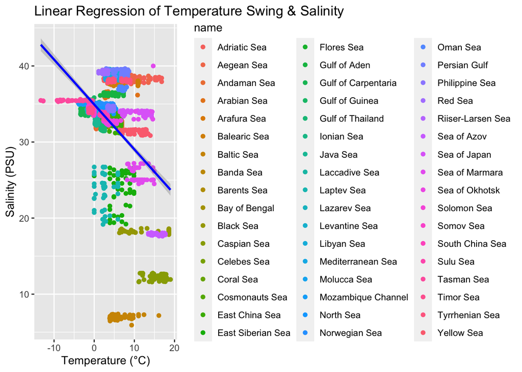

## Distribution Map:

This distribution map provides a visual representation of where data was collected in this study. This map indicates the geographic distribution of what the salinity (PSU) and temperature (°C) levels were when analyzing each point. The distribution map allows us to explore spatial patterns and trends across the various seas. The blue data points indicate where coral was present, whereas the red data points indicate no coral within the tested region. By visualizing the spatial distribution of salinity and temperature, we can uncover valuable insights as to what specific regions of the world are most suitable for coral growth, and what regions are more susceptible to coral bleaching due to major influxes in salinity and temperature.

[interactive chart not shown]

## Conclusion:

If I were to do this project again, I would add a heat map over the distribution map to help visualize the data on a deeper level. I would also try and make statistical models to predict what future variables may appear in their specific region. The main thing I learned about R from this project was how to build an interactive distribution map. I hope to be able to continue to build on the skills taught in this class.